# Gene Enrichment Analysis

Published

April 29, 2026

### Gene Set Enrichment Analysis (GSEA)

Gene Set Enrichment Analysis (GSEA) was performed to identify biological pathways systematically altered by APOE2 overexpression in glial cells. This method evaluates whether genes within predefined gene sets are randomly distributed throughout a ranked gene list or concentrated at the extremes, indicating coordinated regulation of biological processes. All genes from the differential expression analysis were ranked by `log2 fold change` and tested against Gene Ontology Biological Process (GO:BP) gene sets from `MSigDB` for Mus musculus (minimum 30 genes, maximum 500 genes per pathway).

> GSEA of brain tissue revealed 200 significantly enriched pathways (>30 genes /pathway, FDR < 0.01)

#### Reducing Redundant Pathways with `collapsePathways`

To reduce redundancy arising from overlapping gene membership between related pathways, the `collapsePathways` function from the `fgsea` package was applied, consolidating the results to the most significantly enriched pathway from each cluster.

```
Original significant pathways: 200
```

```
After collapsing: 60
```

Results are reported as Normalized Enrichment Score (NES, indicating direction and magnitude of enrichment), adjusted p-value (padj, statistical significance after FDR correction), size (number of genes in the pathway present in the dataset), and the leading-edge gene count (the subset of pathway genes driving the enrichment signal — used here as a per-pathway effect-size measure).

| Pathway | NES | padj | Size | Leading-edge genes (n) |
| --- | --- | --- | --- | --- |
| TRANSLATION AT SYNAPSE | 3.122 | 0.000 | 48 | 47 |
| MITOCHONDRIAL RESPIRATORY CHAIN COMPLEX ASSEMBLY | 2.905 | 0.000 | 117 | 91 |
| CYTOPLASMIC TRANSLATION | 2.740 | 0.000 | 162 | 93 |
| PROTON MOTIVE FORCE DRIVEN ATP SYNTHESIS | 2.739 | 0.000 | 72 | 55 |
| OXIDATIVE PHOSPHORYLATION | 2.707 | 0.000 | 144 | 107 |
| CELLULAR RESPIRATION | 2.567 | 0.000 | 232 | 137 |
| POSITIVE REGULATION OF CELL KILLING | 2.322 | 0.000 | 53 | 22 |
| CELL KILLING | 2.270 | 0.000 | 152 | 59 |
| ANTIGEN PROCESSING AND PRESENTATION OF PEPTIDE ANTIGEN | 2.248 | 0.000 | 53 | 25 |
| MITOCHONDRIAL TRANSLATION | 2.139 | 0.000 | 129 | 66 |
| ANTIMICROBIAL HUMORAL IMMUNE RESPONSE MEDIATED BY ANTIMICROBIAL PEPTIDE | 2.025 | 0.002 | 51 | 24 |
| GLUTATHIONE METABOLIC PROCESS | 1.926 | 0.002 | 54 | 26 |
| POSITIVE REGULATION OF IMMUNE EFFECTOR PROCESS | 1.883 | 0.000 | 215 | 60 |
| XENOBIOTIC METABOLIC PROCESS | 1.882 | 0.006 | 58 | 27 |
| DEFENSE RESPONSE TO VIRUS | 1.878 | 0.000 | 272 | 91 |
| ORGANIC ACID CATABOLIC PROCESS | 1.751 | 0.001 | 200 | 93 |
| NEGATIVE REGULATION OF EPITHELIAL CELL PROLIFERATION | 1.676 | 0.007 | 147 | 42 |
| FATTY ACID METABOLIC PROCESS | 1.663 | 0.000 | 341 | 139 |
| MITOCHONDRIAL TRANSPORT | 1.648 | 0.006 | 171 | 64 |
| CHROMOSOME ORGANIZATION | -1.483 | 0.002 | 483 | 182 |
| POSITIVE REGULATION OF DNA METABOLIC PROCESS | -1.559 | 0.003 | 290 | 106 |
| NUCLEAR TRANSPORT | -1.588 | 0.001 | 341 | 160 |
| CYTOSKELETON DEPENDENT INTRACELLULAR TRANSPORT | -1.658 | 0.002 | 201 | 95 |
| COGNITION | -1.671 | 0.000 | 375 | 148 |
| HORMONE MEDIATED SIGNALING PATHWAY | -1.672 | 0.003 | 184 | 77 |
| CILIUM ORGANIZATION | -1.676 | 0.000 | 408 | 131 |
| PROTEIN CONTAINING COMPLEX LOCALIZATION | -1.678 | 0.001 | 267 | 126 |
| POSITIVE REGULATION OF CELL PROJECTION ORGANIZATION | -1.684 | 0.000 | 432 | 169 |
| EPIGENETIC REGULATION OF GENE EXPRESSION | -1.688 | 0.001 | 254 | 127 |
| DEVELOPMENTAL CELL GROWTH | -1.710 | 0.001 | 267 | 107 |
| PROTEIN AUTOPHOSPHORYLATION | -1.724 | 0.001 | 183 | 106 |
| RESPONSE TO CALCIUM ION | -1.731 | 0.002 | 140 | 49 |
| ADULT BEHAVIOR | -1.731 | 0.001 | 177 | 68 |
| REGULATION OF ORGANELLE ASSEMBLY | -1.765 | 0.000 | 239 | 107 |
| REGULATION OF MICROTUBULE BASED PROCESS | -1.772 | 0.000 | 253 | 96 |
| EXTRACELLULAR STRUCTURE ORGANIZATION | -1.777 | 0.000 | 289 | 67 |
| FOREBRAIN DEVELOPMENT | -1.798 | 0.000 | 437 | 189 |
| NEURON MIGRATION | -1.828 | 0.000 | 204 | 84 |
| VESICLE MEDIATED TRANSPORT IN SYNAPSE | -1.853 | 0.000 | 306 | 101 |
| REGULATION OF MEMBRANE POTENTIAL | -1.858 | 0.000 | 467 | 168 |
| POSITIVE CHEMOTAXIS | -1.858 | 0.006 | 53 | 17 |
| ADENYLATE CYCLASE INHIBITING G PROTEIN COUPLED RECEPTOR SIGNALING PATHWAY | -1.887 | 0.004 | 68 | 31 |
| REGULATION OF SYNAPTIC PLASTICITY | -1.889 | 0.000 | 262 | 121 |
| REGULATION OF SYNAPTIC TRANSMISSION GLUTAMATERGIC | -1.908 | 0.001 | 81 | 37 |
| DENDRITE DEVELOPMENT | -1.908 | 0.000 | 317 | 147 |
| CALCIUM ION IMPORT | -1.916 | 0.002 | 74 | 29 |
| CELL CELL ADHESION VIA PLASMA MEMBRANE ADHESION MOLECULES | -1.919 | 0.000 | 199 | 86 |
| REGULATION OF SYNAPSE STRUCTURE OR ACTIVITY | -1.950 | 0.000 | 391 | 182 |
| MRNA PROCESSING | -1.954 | 0.000 | 465 | 221 |
| CIRCADIAN RHYTHM | -1.962 | 0.000 | 212 | 88 |
| SYNAPSE ASSEMBLY | -1.992 | 0.000 | 294 | 138 |
| POSTSYNAPSE ORGANIZATION | -2.033 | 0.000 | 307 | 143 |
| CENTRAL NERVOUS SYSTEM NEURON DEVELOPMENT | -2.062 | 0.000 | 107 | 58 |
| REGULATION OF MRNA METABOLIC PROCESS | -2.064 | 0.000 | 272 | 142 |
| NEURON PROJECTION GUIDANCE | -2.138 | 0.000 | 233 | 110 |
| REGULATION OF FEEDING BEHAVIOR | -2.158 | 0.000 | 33 | 20 |
| SPLICEOSOMAL COMPLEX ASSEMBLY | -2.186 | 0.000 | 50 | 33 |
| GLUTAMATE RECEPTOR SIGNALING PATHWAY | -2.188 | 0.000 | 58 | 32 |
| NEURON RECOGNITION | -2.265 | 0.000 | 52 | 34 |
| REGULATION OF POSTSYNAPTIC MEMBRANE POTENTIAL | -2.355 | 0.000 | 153 | 75 |

#### Key Enriched Pathways

The most prominently upregulated pathways were associated with protein synthesis and mitochondrial energy metabolism. Immune response pathways also showed significant upregulation. In contrast, pathways involved in neuronal function and synaptic regulation were predominantly downregulated. The number at the tip of each bar indicates the leading-edge gene count — the genes within each pathway that contribute to the enrichment signal — included as a per-pathway measure of effect size.

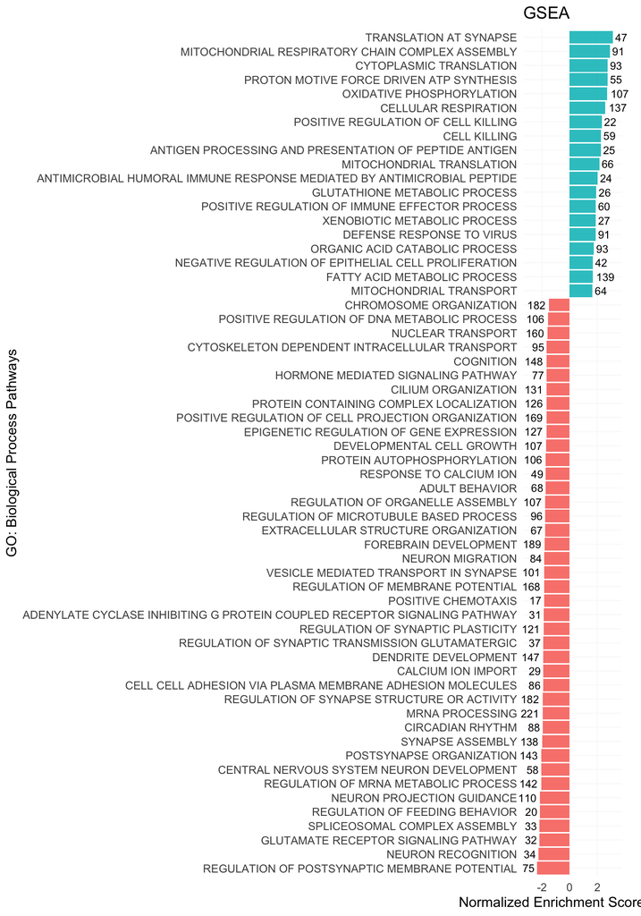

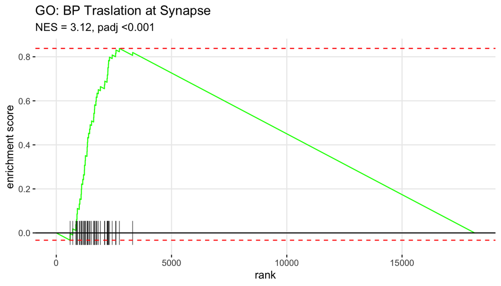

```
Eef2, Rpl10, Rpl10a, Rpl12, Rpl13, Rpl13a, Rpl14, Rpl15, Rpl17, Rpl22, Rpl23, Rpl23a, Rpl24, Rpl26, Rpl27, Rpl27a, Rpl28, Rpl29, Rpl32, Rpl34, Rpl35, Rpl35a, Rpl36, Rpl36a, Rpl37, Rpl37a, Rpl38, Rpl4, Rpl5, Rpl6, Rpl7, Rpl7a, Rpl8, Rpl9, Rplp2, Rps10, Rps11, Rps12, Rps14, Rps15a, Rps16, Rps24, Rps26…
```

[figure not shown]

```
Antkmt, Atg5lrt, Atp5f1a, Atp5f1b, Atp5f1c, Atp5f1d, Atp5f1e, Atp5if1, Atp5mc1, Atp5mc2, Atp5mc3, Atp5me, Atp5mf, Atp5mg, Atp5pb, Atp5pd, Atp5pf, Atp5po, Atp6-ps, Atp6v1a, Atpsckmt, Dnajc30, Ndufa1, Ndufa10, Ndufa11, Ndufa12, Ndufa13, Ndufa2, Ndufa3, Ndufa5, Ndufa6, Ndufa7, Ndufa8, Ndufa9, Ndufab1, …
```

[figure not shown]

```
2410137M14Rik, Azgp1, B2m, Bag6, Calr, Cd74, Clec4a2, Clec4a3, Clec4a4, Ctse, Ctsl, Ctss, Fcer1g, Fcgr1, Fcgr2b, Fcgr3, H2-Aa, H2-Ab1, H2-D1, H2-DMa, H2-DMb1, H2-DMb2, H2-Ea, H2-Eb1, H2-Eb2, H2-K1, H2-M1, H2-M10.1, H2-M10.2, H2-M10.3, H2-M10.4, H2-M10.5, H2-M10.6, H2-M11, H2-M2, H2-M3, H2-M5, H2-M9,…
```